# Discrete Probability Distributions

Ben Goodrich

February 20, 2022

# Variance

- Let $g\left(X\right) = \left(X - \mu\right)^2$ for a discrete random variable, $X$, with expectation $\mu$:
  $$\mathbb{E}g\left(X\right) = \sum_{x\in\Omega}\left(x - \mu\right)^2\times\Pr\left(x\right) = \sigma^2 \geq 0$$
  is the VARIANCE of $X$ but the EXPECTATION of the random variable $g$. Since $\left(X-\mu\right)^{2} = X^2 - 2X\mu + \mu^2$, we can rewrite the variance of $X$ as
  $$\sigma^2 = \sum_{x\in\Omega}\left(x^2 - 2x\mu + \mu^2\right)\times\Pr\left(x\right) \\
  = \sum_{x\in\Omega}x^2 \times \Pr\left(x\right) - 2\mu\sum_{x\in\Omega}x \times \Pr\left(x\right) +
  \mu^2 \sum_{x\in\Omega} \Pr\left(x\right) \\
  = \mathbb{E}\left[X^2\right] - 2\mu^2 + \mu^2 = \mathbb{E}\left[X^2\right] - \mu^2$$
- $\sigma = \sqrt[+]{\sigma^{2}}$ is the STANDARD DEVIATION of $X$

# Covariance and Correlation between Two RVs

# Bernoulli Distribution

- The Bernoulli distribution over $\Omega=\left\{ 0,1\right\}$ depends on a possibly unknown probability parameter $\pi \in \left[0,1\right]$ (not $3.14159\dots$)
- The probability that $x = 1$ (“success”) is $\pi$ and the probability that $x = 0$ (“failure”) is $1 - \pi$
- Can write as a Probability Mass Function (PMF) $\Pr\left(x \mid \pi\right)=\pi^{x}\left(1-\pi\right)^{1-x}$ > > - a function that explains all probabilities within the range
- What is the expectation of $X$? >> expectation = $pi$
- What is the variance of $X$?
- You could write a model where $\pi$ is a function of predictors for each observation, as in $\pi\left(z\right) = \frac{1}{1+e^{-\alpha - \beta z}}$ for a logit model with predictor $z$ and then estimate the intercept, $\alpha$, and slope, $\beta$, using Bayes’ Rule (in Week04)

# Binomial Distribution

- A Binomial random variable can be defined as the sum of $n$ INDEPENDENT Bernoulli random variables all with the same $\pi$. What is $\Omega$ in this case?
- What is an expression for the expectation of a Binomial random variable?
- What is an expression for the variance of a Binomial random variable?
- What is an expression for $\Pr\left(x \mid \pi,n=3\right)$? Hint: 8 cases to consider
- All succeed, $\pi^3$ or all fail, $\left(1 - \pi\right)^3$
- 1 succeeds and 2 fail $\pi^1 \left(1-\pi\right)^{3 - 1}$ but there are 3 ways that could happen
- 2 succeed and 1 fails $\pi^2 \left(1-\pi\right)^{3 - 2}$ but there are 3 ways that could happen
- In general, $\Pr\left(x \mid n,\pi\right)={n \choose x}\pi^{x} \left(1-\pi\right)^{n-x} = \frac{n!}{\left(n - x\right)!x!} \pi^{x} \left(1-\pi\right)^{n-x}$

# Back to Bowling Questions

- Why is the binomial distribution with $n = 10$ inappropriate for the first roll of a frame of bowling? — pins are not independent at all!!
- Could the Bernoulli distribution be used for success in getting a strike? — oui
- Could the Bernoulli distribution be used for the probability of knocking over the front most pin? – also oui - marginal probability of first pin could be bernouilli
- If $X_i = \mathbb{I}\{\mbox{pin i is knocked down}\}$ and $\pi_i$ is the probability in the $i$-th Bernoulli distribution, which could be a function of other pins, what conceptually is
  $$\Pr\left(x_1 \mid \pi_1\right)\prod_{i=2}^{10}
  \Pr\left(x_i \mid \pi_i\left(X_1=x_1,X_2=x_2,\dots,X_{i-1}=x_{i-1}\right)\right)?$$
  – concept = joint probability over all events in the sample space (11 events) - we use general multiplication rule 10 times

# Poisson Distribution for Counts

- Let $n\uparrow \infty$ and let $\pi \downarrow 0$ such that $\mu = n\pi$ remains fixed and finite. What is the limit of the binomial PMF, $\Pr\left(x \mid n,\pi\right)={n \choose x}\pi^{x} \left(1-\pi\right)^{n-x}$?
  - ${n \choose x}\pi^{x} = \frac{n!}{x!\left(n - x\right)!} \frac{\mu^x}{n^x} = \frac{n \times \left(n - 1\right) \times \left(n - 2\right) \times \dots \times \left(n - x + 1\right)} {n^x} \frac{\mu^x}{x!} \rightarrow 1 \times \frac{\mu^x}{x!}$
  - $\left(1-\pi\right)^{n-x} = \left(1-\frac{\mu}{n}\right)^{n-x} = \left(1-\frac{\mu}{n}\right)^n \times \left(1-\frac{\mu}{n}\right)^{-x} \rightarrow e^{-\mu} \times 1$
  - Thus, the limiting PMF is $\Pr\left(x \mid \mu\right) = \frac{\mu^xe^{-\mu}}{x!}$, which is the PMF of the Poisson distribution over $\Omega = \{0,\mathbb{Z}_+\}$
- What is the variance of a Poisson random variable? – mean and variance are the same number but refering to different CONCEPTS

# Parameterized Bowling Probabilities

- This is a bit artificial because parameters are usually continuous (see Week04)
- Let $\Pr\left(x \mid n, \Upsilon\right) = \frac{\log_{n + 2 + \Upsilon}\left(1 + \frac{1}{n + 1 + \Upsilon - x}\right)}{1 - \log_{n + 2 + \Upsilon}\left(1 + \Upsilon\right)}$ where $\Upsilon \in \{0,\mathbb{Z}_+\}$ is a parameter

```r
Pr <- function(x, n = 10, Upsilon = 0) {
  b <- n + 2 + Upsilon
  ifelse(x > n, 0, log(1 + 1 / (n + 1 + Upsilon - x), b)) / (1 - log(1 + Upsilon, b))
}
Omega <- 0:10
names(Omega) <- as.character(Omega)
# can define all of the above via source("bowling.R") if Week03 is your working directory
round(t(sapply(c(`0` = 0, `1` = 1, `9` = 9), FUN = Pr, x = Omega, n = 10)), digits = 5)
```

```
        0       1       2       3       4       5       6       7       8       9      10
0 0.03502 0.03836 0.04240 0.04740 0.05374 0.06203 0.07337 0.08980 0.11577 0.16317 0.27894
1 0.04276 0.04649 0.05092 0.05629 0.06292 0.07134 0.08235 0.09740 0.11921 0.15369 0.21662
9 0.06576 0.06913 0.07287 0.07704 0.08171 0.08699 0.09299 0.09988 0.10788 0.11728 0.12846
```

# How to Think about (a prior on) $\Upsilon$

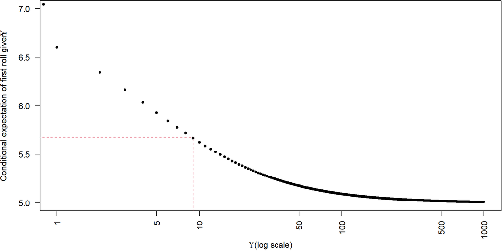

# Joint Probability of $\Upsilon$ and $X_1$

- If you going to collect a realization of the first roll of a frame of bowling, what is $\Pr\left(\Upsilon \bigcap x_1 \mid \mu, n = 10\right)$ under a Poisson prior on $\Upsilon$ with, e.g., $\mu = 8.5$?

```r
mu <- 8.5
Upsilon <- 0:999 # practically infinite, at least relative to mu
joint_Pr <- matrix(NA, nrow = length(Upsilon), ncol = length(Omega), dimnames = list(Upsilon, Omega))
# dpois() evaluates the Poisson PMF with expectation mu: mu^y * exp(-mu) / factorial(y)
for (y in Upsilon) joint_Pr[y + 1, ] <- dpois(y, mu) * Pr(Omega, n = 10, Upsilon = y)
round(joint_Pr, digits = 6) # can View(joint_Pr) in RStudio to see more rows
```

```
##            0        1        2        3        4        5        6        7        8        9       10
## 0   0.000007 0.000008 0.000009 0.000010 0.000011 0.000013 0.000015 0.000018 0.000024 0.000033 0.000057
## 1   0.000074 0.000080 0.000088 0.000097 0.000109 0.000123 0.000142 0.000168 0.000206 0.000266 0.000375
## 2   0.000354 0.000382 0.000415 0.000455 0.000503 0.000562 0.000637 0.000736 0.000870 0.001065 0.001373
## 3   0.001087 0.001168 0.001261 0.001371 0.001502 0.001660 0.001856 0.002104 0.002429 0.002873 0.003516
## 4   0.002456 0.002625 0.002820 0.003045 0.003311 0.003626 0.004009 0.004481 0.005081 0.005865 0.006937
## 5   0.004379 0.004662 0.004984 0.005353 0.005782 0.006286 0.006885 0.007611 0.008508 0.009646 0.011136
## 6   0.006450 0.006841 0.007283 0.007786 0.008363 0.009033 0.009819 0.010756 0.011890 0.013292 0.015069
## 7   0.008089 0.008552 0.009071 0.009656 0.010323 0.011088 0.011976 0.013018 0.014260 0.015764 0.017622
## 8   0.008833 0.009311 0.009843 0.010440 0.011114 0.011881 0.012762 0.013784 0.014984 0.016413 0.018144
## 9   0.008540 0.008978 0.009464 0.010005 0.010612 0.011297 0.012077 0.012972 0.014011 0.015230 0.016683
## 10  0.007409 0.007770 0.008169 0.008611 0.009103 0.009655 0.010278 0.010988 0.011802 0.012747 0.013857
## 11  0.005828 0.006099 0.006397 0.006725 0.007089 0.007494 0.007949 0.008462 0.009046 0.009716 0.010495
## 12  0.004194 0.004381 0.004585 0.004808 0.005055 0.005328 0.005633 0.005975 0.006360 0.006799 0.007303
## 13  0.002781 0.002900 0.003029 0.003170 0.003324 0.003495 0.003684 0.003894 0.004131 0.004397 0.004701
```

[output cut: 986 more lines]

# Marginal Probability of $X_1$

- What are the dimensions of `joint_Pr` and the value of `sum(joint_Pr)`?

```r
dim(joint_Pr); sum(joint_Pr)
```

```
## [1] 1000   11
```

```
## [1] 1
```

- How do we obtain $\Pr\left(\bcancel{\Upsilon} \bigcap x_1 \mid \mu = 8.5, n = 10\right)$?

```r
marginal_Pr <- colSums(joint_Pr)
round(marginal_Pr, digits = 5)
```

```
##       0       1       2       3       4       5       6       7       8       9      10
## 0.06419 0.06761 0.07143 0.07571 0.08057 0.08611 0.09251 0.10001 0.10891 0.11973 0.13323
```

# What is $\Pr\left(\Upsilon \mid \mu = 8.5, n = 10, x_1 = 7\right)$?

```r
library(dplyr)
library(ggplot2)
S <- 10^7 # practically infinite
tibble(Upsilon = rpois(S, mu)) %>% # draw S times from a Poisson with expectation mu
  group_by(Upsilon) %>%
  mutate(x_1 = sample(Omega, size = n(), replace = TRUE,
                      prob = Pr(Omega, n = 10, first(Upsilon)))) %>%
  ungroup %>%
  filter(x_1 == 7) %>%
  count(Upsilon, name = "simulated") %>%
  mutate(simulated = simulated / sum(simulated), # close to exact for finite S
         exact = joint_Pr[Upsilon + 1, "7"] / marginal_Pr["7"]) %>%
  ggplot(mapping = aes(x = Upsilon, y = simulated)) + geom_col() +            # posterior
  stat_function(geom = "point", color = "red", fun = ~dpois(round(.x), mu)) + # prior
  ylim(0, 0.14)
# plot on next slide
```

# Simulated $\Pr\left(\Upsilon \mid \mu = 8.5, n = 10, x_1 = 7\right)$

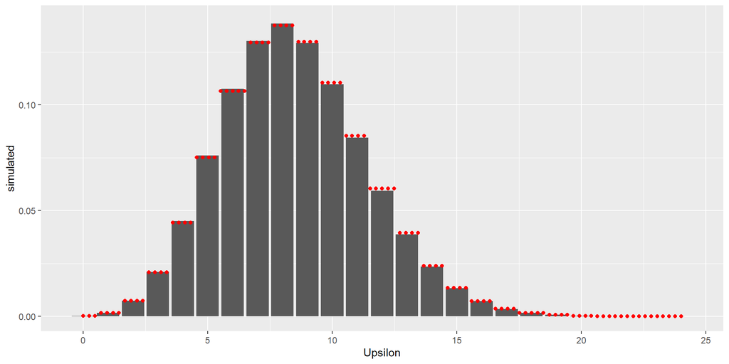

# Joint Probability of $\Upsilon$, $X_1$, and $X_2$ $\mid \mu = 8.5$

```r
joint_Pr_frame <- array(NA, dim = c(length(Upsilon), length(Omega), length(Omega)),
                        dimnames = list(Upsilon, Omega, Omega))
for (y in Upsilon) {
  prior <- dpois(y, mu) # scalar
  cPr_x_1 <- Pr(Omega, n = 10, Upsilon = y) # vector of size 11
  cPr_x_2 <- t(sapply(Omega, FUN = function(x_1) { # 11x11 matrix
    Pr(Omega, n = 10 - x_1, Upsilon = y)
  }))
  joint_Pr_frame[y + 1, , ] <- prior * cPr_x_1 * cPr_x_2 # elementwise multiplication
} # this is correct but relies on R's recycling conventions
dim(joint_Pr_frame)
```

```
## [1] 1000   11   11
```

```r
sum(joint_Pr_frame)
```

```
## [1] 1
```

# $\Pr\left(\bcancel{\Upsilon} \bigcap x_1 \bigcap x_2 \mid \mu = 8.5, n = 10\right)$

```r
marginal_Pr_frame <- apply(joint_Pr_frame, MARGIN = 2:3, FUN = sum) # shown below
```

|  | 0 | 1 | 2 | 3 | 4 | 5 | 6 | 7 | 8 | 9 | 10 |
| --- | --- | --- | --- | --- | --- | --- | --- | --- | --- | --- | --- |
| 0 | 0.0041431 | 0.0043614 | 0.0046047 | 0.0048776 | 0.005186 | 0.0055377 | 0.005943 | 0.0064157 | 0.0069758 | 0.0076522 | 0.0084914 |
| 1 | 0.0049099 | 0.0051839 | 0.0054912 | 0.0058387 | 0.0062348 | 0.0066913 | 0.007224 | 0.007855 | 0.0086174 | 0.0095633 | 0 |
| 2 | 0.0059041 | 0.0062543 | 0.0066502 | 0.0071018 | 0.0076221 | 0.0082293 | 0.0089488 | 0.0098181 | 0.010897 | 0 | 0 |
| 3 | 0.0072253 | 0.007683 | 0.0082051 | 0.0088068 | 0.0095089 | 0.0103411 | 0.0113469 | 0.0125953 | 0 | 0 | 0 |
| 4 | 0.0090356 | 0.0096501 | 0.0103584 | 0.0111852 | 0.0121652 | 0.01335 | 0.0148211 | 0 | 0 | 0 | 0 |
| 5 | 0.0116137 | 0.0124672 | 0.0134635 | 0.0146448 | 0.0160733 | 0.017848 | 0 | 0 | 0 | 0 | 0 |
| 6 | 0.0154775 | 0.0167163 | 0.0181855 | 0.0199629 | 0.0221722 | 0 | 0 | 0 | 0 | 0 | 0 |
| 7 | 0.0216932 | 0.0236039 | 0.0259166 | 0.0287931 | 0 | 0 | 0 | 0 | 0 | 0 | 0 |
| 8 | 0.0328161 | 0.0360414 | 0.0400568 | 0 | 0 | 0 | 0 | 0 | 0 | 0 | 0 |
| 9 | 0.0566889 | 0.0630363 | 0 | 0 | 0 | 0 | 0 | 0 | 0 | 0 | 0 |
| 10 | 0.133227 | 0 | 0 | 0 | 0 | 0 | 0 | 0 | 0 | 0 | 0 |

# Posterior Distribution Conditional on One Frame

- If $x_1 = 7$ and $x_2 = 2$, what is $\Pr\left(\Upsilon \mid \mu = 8.5, n = 10, x_1 = 7, x_2 = 2\right)$?

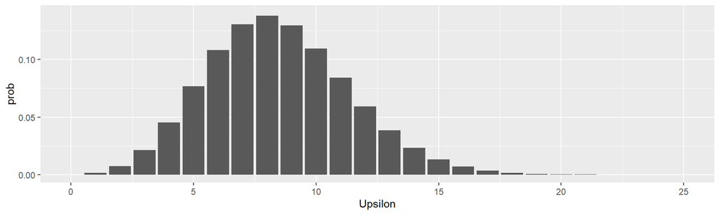

```r
ggplot(tibble(Upsilon,
              prob = joint_Pr_frame[ , "7", "2"] / marginal_Pr_frame["7", "2"])) +
  geom_col(aes(x = Upsilon, y = prob)) + xlim(0, 25) + ylim(0, 0.14)
```

# Bayesian Learning

- If we use the posterior PMF, `joint_Pr[ , "7"] / marginal_Pr["7"]`, as a “prior” for the second roll, what is $\Pr\left(\Upsilon \mid \mu = 8.5, n = 10 - 7, x_2 = 2\right)$?

```r
prior <- joint_Pr[ , "7"] / marginal_Pr["7"] # = Pr(Upsilon | mu = 8.5, n = 10, x_1 = 7)
likelihood <- sapply(Upsilon, FUN = Pr, x = 2, n = 10 - 7) # for each value of Upsilon
numerator <- prior * likelihood
round(rbind("2 step" = head(numerator, 23) / sum(numerator),
            "1 leap" = head(joint_Pr_frame[ , "7", "2"], 23) / marginal_Pr_frame["7", "2"],
            "prior"  = dpois(0:22, mu)), digits = 5)
```

```
             0       1       2       3       4       5       6       7       8       9      10      11
2 step 0.00018 0.00170 0.00747 0.02135 0.04535 0.07677 0.10815 0.13053 0.13785 0.12943 0.10941 0.08411
1 leap 0.00018 0.00170 0.00747 0.02135 0.04535 0.07677 0.10815 0.13053 0.13785 0.12943 0.10941 0.08411
prior  0.00020 0.00173 0.00735 0.02083 0.04425 0.07523 0.10658 0.12942 0.13751 0.12987 0.11039 0.08530
            12      13      14      15      16      17      18      19      20      21      22
2 step 0.05929 0.03859 0.02333 0.01317 0.00697 0.00347 0.00163 0.00073 0.00031 0.00012 0.00005
1 leap 0.05929 0.03859 0.02333 0.01317 0.00697 0.00347 0.00163 0.00073 0.00031 0.00012 0.00005
prior  0.06042 0.03951 0.02399 0.01359 0.00722 0.00361 0.00170 0.00076 0.00032 0.00013 0.00005
```

# Posterior Draws Given that $x_1 = 7$ & $x_2 = 2$

```r
tibble(Upsilon = rpois(S, mu)) %>%
  group_by(Upsilon) %>%

  filter(7 == # condition on roll 1
           sample(Omega,
                  size = n(),
                  replace = TRUE,
                  prob = Pr(Omega,
                            n = 10,
                            first(Upsilon)))) %>%
  filter(2 == # condition on roll 2
           sample(Omega,
                  size = n(),
                  replace = TRUE,
                  prob = Pr(Omega,
                            n = 10 - 7,
                            first(Upsilon)))) %>%
  ungroup %>%

  count(Upsilon, name = "simulated") %>%
  mutate(simulated = simulated /
                     sum(simulated),
         exact = joint_Pr_frame[Upsilon + 1,
                                "7", "2"] /
                 marginal_Pr_frame["7", "2"]) %>%
  print(n = 22)
```

```
## # A tibble: 26 x 3
##    Upsilon simulated    exact
##      <int>     <dbl>    <dbl>
##  1       0  0.000182 0.000178
##  2       1  0.00180  0.00170
##  3       2  0.00739  0.00747
##  4       3  0.0209   0.0214
##  5       4  0.0452   0.0453
##  6       5  0.0767   0.0768
##  7       6  0.109    0.108
##  8       7  0.131    0.131
##  9       8  0.139    0.138
## 10       9  0.129    0.129
## 11      10  0.109    0.109
## 12      11  0.0834   0.0841
## 13      12  0.0596   0.0593
## 14      13  0.0388   0.0386
## 15      14  0.0230   0.0233
## 16      15  0.0134   0.0132
## 17      16  0.00674  0.00697
## 18      17  0.00362  0.00347
## 19      18  0.00155  0.00163
## 20      19  0.000753 0.000729
## 21      20  0.000332 0.000309
## 22      21  0.000131 0.000125
## # ... with 4 more rows
```

# Posterior Distribution Conditional on One Game

```r
game <- rbind(
  `1st` = c(7, 2), `2nd` = c(7, 1), `3rd` = c(10, 0), `4th` = c(5, 3),  `5th` = c(9, 1),
  `6th` = c(6, 1), `7th` = c(8, 2), `8th` = c(4,  5), `9th` = c(7, 3), `10th` = c(8, 1) )
log_prior <- dpois(Upsilon, mu, log = TRUE) # use (natural) logs for numerical reasons
log_likelihood <- sapply(Upsilon, FUN = function(y) {
  sum(log(Pr(x = game[ , 1], n = 10, Upsilon = y)),
      log(Pr(x = game[ , 2], n = 10 - game[ , 1], Upsilon = y)))
  })
numerator <- exp(log_prior + log_likelihood) # convert back to probability units
denominator <- sum(numerator)
```

```r
ggplot(tibble(Upsilon,
              prob = numerator / denominator)) +
  geom_col(aes(x = Upsilon, y = prob)) + xlim(0, 25) + ylim(0, 0.14) # plot on next slide
```

# Plot from Previous Slide

[figure not shown]

# Takeaways from Homework 1

- Probability requires discipline and concentration
- Poker simultaneously combines three perspectives on probability
  - Naive: All non-visible cards have equal probability
  - Bayesian: A hand is a sequence of decisions
  - Frequentist: Evaluate a strategy / player over thousands of hands
- And poker illustrates game theory where players have mixed strategies, where they randomly make one decision with probability $\pi$ and another decision with probability $1 - \pi$ in the exact same situation
- What would Fisher say about Selbst’s last decision to call?
- Knowing either that my last name is Goodrich or that I live in Manhattan is sufficient to make it more likely that I am white than any other race, but combined the probability is even higher